# Сравнение RFM анализа, сделанного 3 способами: ручным способом, с отсечением выбросов, K-Means

### В бизнес-контексте: Алгоритм кластеризации — это метод, который помогает сегментировать клиентов, то есть процесс классификации похожих клиентов в один и тот же сегмент. Алгоритм кластеризации помогает лучше понять клиентов с точки зрения как статической демографии, так и динамического поведения. Клиенты с сопоставимыми характеристиками часто взаимодействуют с бизнесом одинаково, поэтому бизнес может извлечь выгоду из этой методики, создав индивидуальную маркетинговую стратегию для каждого сегмента. Исходя из этого, клиентам могут быть предоставлены скидки, предложения, промокоды и т. д. В качестве простого примера. Предприятие хочет предложить своим клиентам скидки. В настоящее время они изучают детали каждого клиента и на основе этой информации решают, какое предложение следует сделать тому или иному клиенту. У фирмы потенциально могут быть тысячи клиентов. Имеет ли смысл смотреть детали каждого клиента отдельно, а потом уже принимать решение? Конечно нет! Это ручной процесс и займет огромное количество времени. Итак, что может сделать отдел маркетинга фирмы? Один из вариантов — разделить клиентов на разные группы. Например, фирма может группировать клиентов по RFM-анализу.

Аббревиатура RFM расшифровывается:

Recency — давность (как давно ваши клиенты были у вас на процедурах). Высокий показатель давности означает, что у клиента уже сложилось достаточно хорошее впечатление о вашем бренде, поэтому он недавно посещал вас. Давность в срезе клиентской базы можно посмотреть, если отсортировать клиентов по дате последней покупки.

Frequency — частота (как часто они у вас покупают). Высокий показатель частоты говорит о том, что клиенту нравится ваш бренд, ваши товары и услуги, поэтому он часто к вам возвращается. Для расчета частоты посещения нужно общее кол-во покупок/визитов разделить на кол-во месяцев/дней/годов и т.д.

Monetary — деньги (общая сумма трат). Высокий уровень этого показателя означает, что клиенту нравится тратить именно у вас.

```python
import os
```

```python
os.chdir('d:/TableauData/Data_customer/')
```

```python
os.listdir('.')
```

```
['Customer DataSet.csv', 'customer-full.csv', 'customer_total.csv']
```

```python
import pandas as pd
import numpy as np
import matplotlib.pyplot as plt
import seaborn as sns
from datetime import date, datetime, timedelta as dt
%matplotlib inline

from scipy import stats
import random

from sklearn.preprocessing import StandardScaler
from sklearn.cluster import KMeans

# from sklearn.cluster import DBSCAN
```

```python
df = pd.read_csv('customer_total.csv')
```

```python
df.info()
```

```
<class 'pandas.core.frame.DataFrame'>
RangeIndex: 341187 entries, 0 to 341186
Data columns (total 14 columns):
 #   Column       Non-Null Count   Dtype
---  ------       --------------   -----
 0   Unnamed: 0   341187 non-null  int64
 1   order_id     341187 non-null  int64
 2   customer_id  341187 non-null  object
 3   order_date   341187 non-null  object
 4   price        341187 non-null  int64
 5   age          341187 non-null  int64
 6   job          341187 non-null  object
 7   marital      341187 non-null  object
 8   education    341187 non-null  object
 9   housing      341187 non-null  object
 10  loan         341187 non-null  object
 11  contact      341187 non-null  object
 12  campaign     341187 non-null  int64
 13  month        341187 non-null  int64
dtypes: int64(6), object(8)
memory usage: 36.4+ MB
```

```python
df['order_date']=pd.to_datetime(df['order_date'], format="%Y-%m-%d")
```

```python
df.describe().style.background_gradient(cmap='YlGnBu')
```

|  | Unnamed: 0 | order_id | price | age | campaign | month |
| --- | --- | --- | --- | --- | --- | --- |
| count | 341187.000000 | 341187.000000 | 341187.000000 | 341187.000000 | 341187.000000 | 341187.000000 |
| mean | 170593.000000 | 170594.000000 | 1197.880514 | 40.010613 | 2.561710 | 6.520553 |
| std | 98492.347484 | 98492.347484 | 662.398822 | 10.444848 | 2.744663 | 3.447105 |
| min | 0.000000 | 1.000000 | 50.000000 | 17.000000 | 1.000000 | 1.000000 |
| 25% | 85296.500000 | 85297.500000 | 625.000000 | 32.000000 | 1.000000 | 4.000000 |
| 50% | 170593.000000 | 170594.000000 | 1197.000000 | 38.000000 | 2.000000 | 7.000000 |
| 75% | 255889.500000 | 255890.500000 | 1770.500000 | 47.000000 | 3.000000 | 10.000000 |
| max | 341186.000000 | 341187.000000 | 2345.000000 | 98.000000 | 56.000000 | 12.000000 |

```python
df.columns
```

```
Index(['Unnamed: 0', 'order_id', 'customer_id', 'order_date', 'price', 'age',
       'job', 'marital', 'education', 'housing', 'loan', 'contact', 'campaign',
       'month'],
      dtype='object')
```

# Посмотрим на датасет

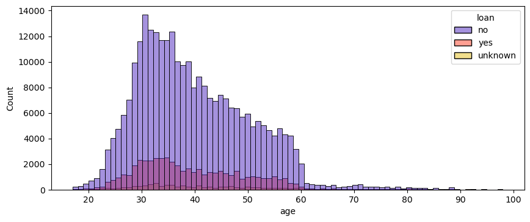

```python
plt.figure(figsize=(10,4),dpi=100)
sns.histplot(data=df, x='age', hue='loan', palette='CMRmap', bins=80)
plt.show()
```

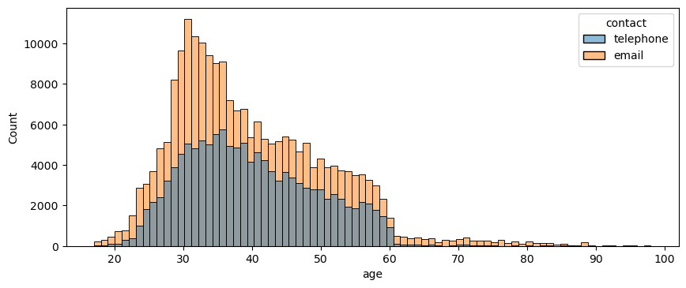

```python
plt.figure(figsize=(10,4),dpi=100)
sns.histplot(data=df,x='age',hue='contact', bins=80)
plt.show()
```

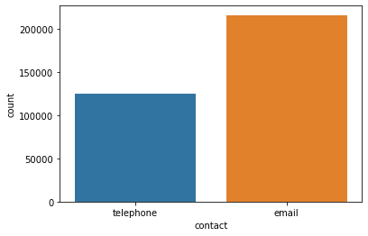

```python
sns.countplot(data=df,x='contact')
```

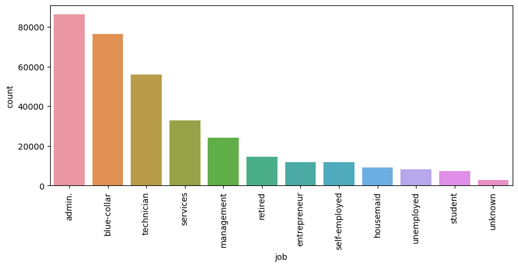

```python
plt.figure(figsize=(10,4),dpi=100)
sns.countplot(data=df,x='job',order=df['job'].value_counts().index)
plt.xticks(rotation=90);
```

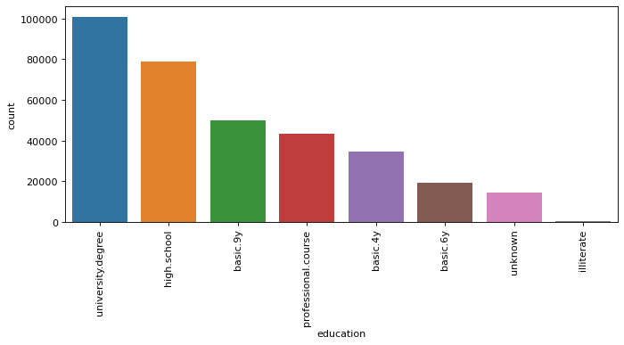

```python
plt.figure(figsize=(10,4),dpi=80)
sns.countplot(data=df, x='education', order=df['education'].value_counts().index)
plt.xticks(rotation=90);
```

Выводы

**В дальнейшем данные можно применить для когортного анализа и исследования закономерностей клиентов**

# Формирование датасета под RFM

```python
last_date_order=df['order_date'].max()
```

```python
rfm= df.groupby('customer_id').agg({'order_date': lambda date: (last_date_order - date.max()).days,
                                        'order_id':'count',
                                        'price':'sum'})\
                            .rename(columns={'order_date':'Recency', 'order_id':'Frequency', 'price':'Monetary'})\
                            .sort_values('Frequency', ascending=False)
```

```python
rfm.head(3)
```

| customer_id | Recency | Frequency | Monetary |
| --- | --- | --- | --- |
| c14618 | 31 | 24 | 31944 |
| c347 | 6 | 22 | 27993 |
| c6977 | 19 | 22 | 23005 |

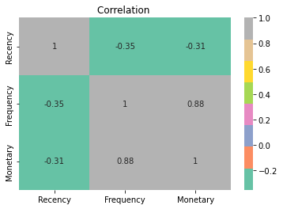

```python
corr=rfm.corr()
fig = plt.figure(figsize=(6,4))
r = sns.heatmap(corr, cmap='Set2', annot=True)
r.set_title("Correlation ")
```

```python
sns.set(context='notebook', style='darkgrid', palette='Set2', font='sans-serif', font_scale=1, color_codes=False, rc=None)
# sns.set_theme(style="whitegrid")
```

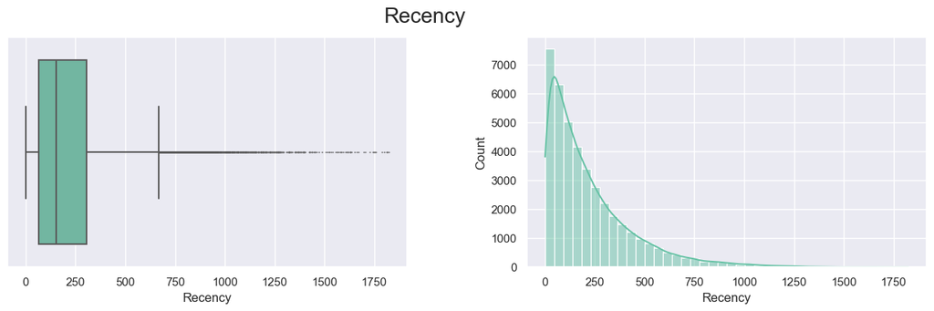

```python
plt.figure(figsize=(11, 4), dpi=100)
plt.subplots_adjust(wspace=0.3, hspace=1, left=0, right=1.1)
plt.suptitle('Recency', fontsize=20)
plt.subplot(121)
sns.boxplot(data=rfm, x='Recency', orient='h', fliersize=0.4)
plt.subplot(122)
sns.histplot(rfm['Recency'], kde=True, bins=40)
plt.show()
```

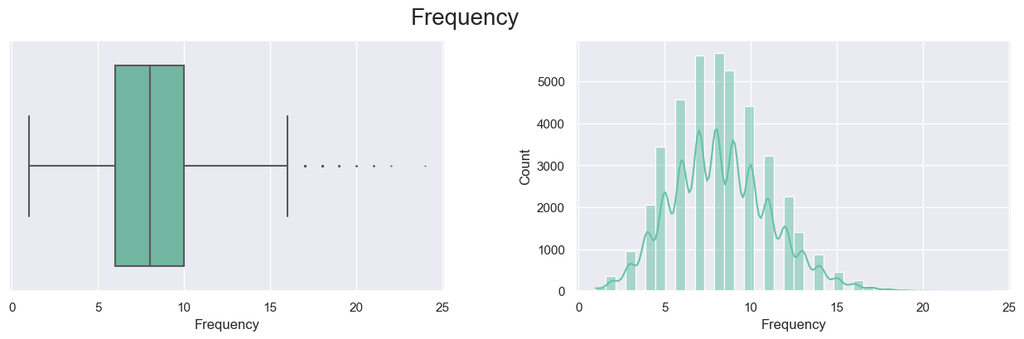

```python
plt.figure(figsize=(11, 4), dpi=100)
plt.subplots_adjust(wspace=0.3, hspace=1, left=0, right=1.1)
plt.suptitle('Frequency', fontsize=20)
plt.subplot(121)
sns.boxplot(data=rfm, x='Frequency', orient='h', fliersize=0.4)
plt.subplot(122)
sns.histplot(rfm['Frequency'], kde=True, bins=40)
plt.show()
```

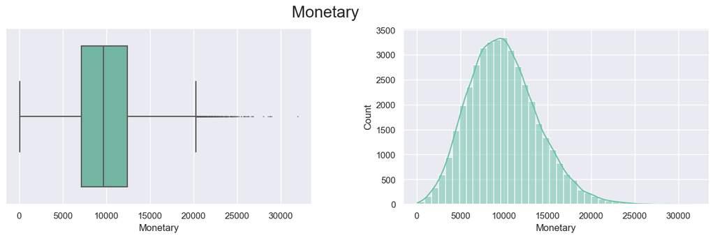

```python
plt.figure(figsize=(11, 4), dpi=100)
plt.subplots_adjust(wspace=0.3, hspace=1, left=0, right=1.1)
plt.suptitle('Monetary', fontsize=20)
plt.subplot(121)
sns.boxplot(data=rfm, x='Monetary', orient='h', fliersize=0.4)
plt.subplot(122)
sns.histplot(rfm['Monetary'], kde=True, bins=40)
plt.show()
```

Выводы

**Заметны выбросы, особенно по Recency (периода до последней покупки). Если по времени (R) выбросы можно отсеить и считать оттоком, то по двум другим кластерам выбросы только требуют изучения**

# Вариант 1. Кластеризация ручным способом. Базовая сегментация

## Для качественного анализа аудитории используем подходы, основанные на сегментации. Используя python, построим RFM-сегментацию пользователей, чтобы качественно оценить свою аудиторию. В кластеризации можешь выбрать следующие метрики: R - время от последней покупки пользователя до текущей даты, F - суммарное количество покупок у пользователя за всё время, M - сумма покупок за всё время.

# Делим на квантили на 5 групп по 20% охвата

```python
# Use quintiles to to make 5 equal parts based on the available values. Each quintiles contains 20% of the population.

quintiles = rfm[['Recency', 'Frequency', 'Monetary']].quantile([.2, .4, .6, .8]).to_dict()
quintiles
```

```
{'Recency': {0.2: 50.0, 0.4: 114.0, 0.6: 203.0, 0.8: 357.0},
 'Frequency': {0.2: 6.0, 0.4: 7.0, 0.6: 9.0, 0.8: 11.0},
 'Monetary': {0.2: 6522.0, 0.4: 8655.0, 0.6: 10641.0, 0.8: 13135.0}}
```

## Функции распределения по кластерам. Чем выше цифра кластера, тем лучше. Максимально - 5. По R (времени) чем меньше - тем больше бал.

```python
def r_score(x):
    if x <= quintiles['Recency'][.2]:
        return 5
    elif x <= quintiles['Recency'][.4]:
        return 4
    elif x <= quintiles['Recency'][.6]:
        return 3
    elif x <= quintiles['Recency'][.8]:
        return 2
    else:
        return 1

def fm_score(x, c):
    if x <= quintiles[c][.2]:
        return 1
    elif x <= quintiles[c][.4]:
        return 2
    elif x <= quintiles[c][.6]:
        return 3
    elif x <= quintiles[c][.8]:
        return 4
    else:
        return 5
```

```python
# Calculate RFM-score for each customer

rfm['R'] = rfm['Recency'].apply(lambda x: r_score(x))
rfm['F'] = rfm['Frequency'].apply(lambda x: fm_score(x, 'Frequency'))
rfm['M'] = rfm['Monetary'].apply(lambda x: fm_score(x, 'Monetary'))
```

```python
rfm.info()
```

```
<class 'pandas.core.frame.DataFrame'>
Index: 41182 entries, c14618 to c28635
Data columns (total 6 columns):
 #   Column     Non-Null Count  Dtype
---  ------     --------------  -----
 0   Recency    41182 non-null  int64
 1   Frequency  41182 non-null  int64
 2   Monetary   41182 non-null  int64
 3   R          41182 non-null  int64
 4   F          41182 non-null  int64
 5   M          41182 non-null  int64
dtypes: int64(6)
memory usage: 2.2+ MB
```

```python
# Combine the scores

rfm['RFM Score'] = rfm['R'].map(str) + rfm['F'].map(str) + rfm['M'].map(str)
```

## Можно придумать несколько вариантов разбиения на группы. В данном случае обозначить целых 6 групп. В основу берем 2 показателя. Признак Monetary пассивно учавствует опосредованно через Frequency

```python
# Created 6 segments based on R and F scores

segments = {
    '[1-2][1-4]': 'at risk',
    '[1-2]5': 'can\'t loose',
    '3[1-3]': 'needs attention',
    '[3-4][4-5]': 'loyal customers',
    '[4-5]1': 'new customers',
    '[4-5][2-5]': 'champions'
}

rfm['Segment'] = rfm['R'].map(str) + rfm['F'].map(str)
rfm['Segment'] = rfm['Segment'].replace(segments, regex=True)
rfm.head()
```

| customer_id | Recency | Frequency | Monetary | R | F | M | RFM Score | Segment |
| --- | --- | --- | --- | --- | --- | --- | --- | --- |
| c14618 | 31 | 24 | 31944 | 5 | 5 | 5 | 555 | champions |
| c347 | 6 | 22 | 27993 | 5 | 5 | 5 | 555 | champions |
| c6977 | 19 | 22 | 23005 | 5 | 5 | 5 | 555 | champions |
| c41082 | 23 | 21 | 28923 | 5 | 5 | 5 | 555 | champions |
| c15613 | 140 | 21 | 22829 | 3 | 5 | 5 | 355 | loyal customers |

```python
# count the number of customers in each segment
segments_counts = rfm['Segment'].value_counts().sort_values(ascending=True)

segments_counts
```

```
can't loose         1126
new customers       3098
needs attention     5265
loyal customers     6112
champions          10261
at risk            15320
Name: Segment, dtype: int64
```

Почему-то больше всего клиентов находится в сегменте "at risk". Такова ручная классификация, которая требует интерпретации у специалистов. Например, у руководства или менеджеров. В каждой сфере можно выделить свои особенности.

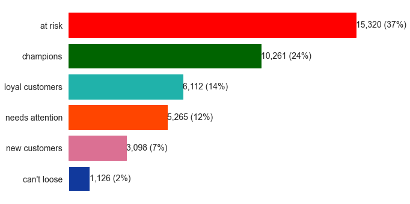

```python
# Distribution of Segments
fig, ax = plt.subplots()
fig.set_figwidth(9)
fig.set_figheight(6)
bars = ax.barh(range(len(segments_counts)),
              segments_counts,
              color='#11399c')
ax.set_frame_on(False)
ax.tick_params(left=False,
               bottom=False,
               labelbottom=False)
ax.set_yticks(range(len(segments_counts)))
ax.set_yticklabels(segments_counts.index)
ax.yaxis.set_tick_params(rotation=0, labelsize=14)

for i, bar in enumerate(bars):
        value = bar.get_width()
        if segments_counts.index[i] in ['champions']:
            bar.set_color('#006400')
        if segments_counts.index[i] in ['loyal customers']:
            bar.set_color('#20B2AA')
        if segments_counts.index[i] in ['at risk']:
            bar.set_color('red')
        if segments_counts.index[i] in ['needs attention']:
            bar.set_color('#FF4500')
        if segments_counts.index[i] in ['new customers']:
            bar.set_color('#DB7093')
        ax.text(value,
                bar.get_y() + bar.get_height()/2,
                '{:,} ({:}%)'.format(int(value),
                                   int(value*100/segments_counts.sum())),
                va='center',
                ha='left',
                fontsize=14
               )

plt.show()
```

Выводы

**Группа "at_risk" самая большая. Основа**

# Вариант 2. Нормализуем данные для отсечения выбросов статистическим методом

```python
# Calculate Z scores to normalize the data

z = np.abs(stats.zscore(rfm[['Recency', 'Frequency', 'Monetary']]))
z.head()
```

| customer_id | Recency | Frequency | Monetary |
| --- | --- | --- | --- |
| c14618 | 0.866157 | 5.445472 | 5.585029 |
| c347 | 0.979995 | 4.752450 | 4.582907 |
| c6977 | 0.920799 | 4.752450 | 3.317763 |
| c41082 | 0.902585 | 4.405939 | 4.818790 |
| c15613 | 0.369822 | 4.405939 | 3.273123 |

## Определим минимальный диапозон в 1% и 99% и посмотрим визуально

```python
z.describe(percentiles=[.01, .05, .95, .99]).style.background_gradient(cmap='YlGnBu')
```

|  | Recency | Frequency | Monetary |
| --- | --- | --- | --- |
| count | 41182.000000 | 41182.000000 | 41182.000000 |
| mean | 0.738439 | 0.798217 | 0.795799 |
| std | 0.674328 | 0.602378 | 0.605568 |
| min | 0.000987 | 0.098706 | 0.000068 |
| 1% | 0.014647 | 0.098706 | 0.012106 |
| 5% | 0.067316 | 0.098706 | 0.061819 |
| 50% | 0.638481 | 0.594316 | 0.674744 |
| 95% | 2.002565 | 1.980361 | 1.930496 |
| 99% | 3.632728 | 2.673383 | 2.648921 |
| max | 7.298317 | 5.445472 | 5.585029 |

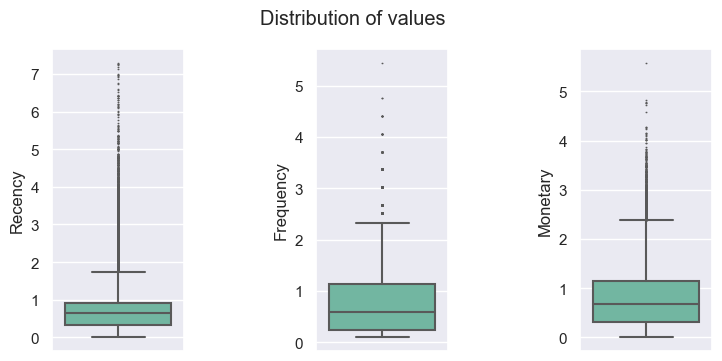

```python
plt.figure(figsize=(6, 4), dpi=100)
plt.subplots_adjust(wspace=1, hspace=1, left=0, right=1.1)
plt.suptitle('Distribution of values')
plt.subplot(131)
sns.boxplot(data=z, y='Recency', fliersize=0.4)
plt.subplot(132)
sns.boxplot(data=z, y='Frequency', fliersize=0.4)
plt.subplot(133)
sns.boxplot(data=z, y='Monetary', fliersize=0.4)
plt.show()
```

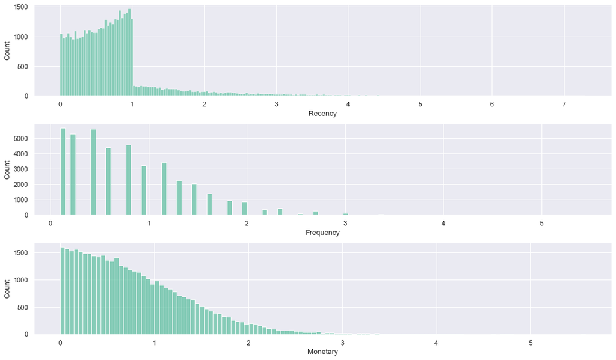

```python
plt.figure(figsize=(12, 10), dpi=80)
plt.subplots_adjust(wspace=1, hspace=0.3, left=0, right=1.1)
plt.subplot(311)
sns.histplot(z['Recency'])
plt.subplot(312)
sns.histplot(z['Frequency'])
plt.subplot(313)
sns.histplot(z['Monetary'])
plt.show()
```

## Коэффициенты определены. Возьмем 1% отсечения. В основном по времени (R)

```python
# Cut out explicit emissions
rfm_z = z.query("Recency < 3.63 & Frequency > 0.0987 & Monetary > 0.0121")

print(f'Number of customers (excluding emissions): {len(rfm_z)}')

#Customer churn
print(f'Customer churn: {len(z)-len(rfm_z)}')
```

```
Number of customers (excluding emissions): 40363
Customer churn: 819
```

```python
rfm_z=rfm.merge(rfm_z, on='customer_id', how='right')
```

```python
rfm_z.head()
```

| customer_id | Recency_x | Frequency_x | Monetary_x | R | F | M | RFM Score | Segment | Recency_y | Frequency_y | Monetary_y |
| --- | --- | --- | --- | --- | --- | --- | --- | --- | --- | --- | --- |
| c14618 | 31 | 24 | 31944 | 5 | 5 | 5 | 555 | champions | 0.866157 | 5.445472 | 5.585029 |
| c347 | 6 | 22 | 27993 | 5 | 5 | 5 | 555 | champions | 0.979995 | 4.752450 | 4.582907 |
| c6977 | 19 | 22 | 23005 | 5 | 5 | 5 | 555 | champions | 0.920799 | 4.752450 | 3.317763 |
| c41082 | 23 | 21 | 28923 | 5 | 5 | 5 | 555 | champions | 0.902585 | 4.405939 | 4.818790 |
| c15613 | 140 | 21 | 22829 | 3 | 5 | 5 | 355 | loyal customers | 0.369822 | 4.405939 | 3.273123 |

```python
rfm_z = rfm_z.rename(columns=lambda col: col.replace('_x', ''))
```

```python
# Use quintiles to to make 5 equal parts based on the available values. Each quintiles contains 20% of the population.

quintiles = rfm_z[['Recency', 'Frequency', 'Monetary']].quantile([.2, .4, .6, .8]).to_dict()
quintiles
```

```
{'Recency': {0.2: 49.0, 0.4: 112.0, 0.6: 200.0, 0.8: 348.0},
 'Frequency': {0.2: 6.0, 0.4: 7.0, 0.6: 9.0, 0.8: 11.0},
 'Monetary': {0.2: 6579.400000000001, 0.4: 8670.0, 0.6: 10726.0, 0.8: 13196.0}}
```

```python
# Calculate RFM-score for each customer
rfm_z['R'] = rfm_z['Recency'].apply(lambda x: r_score(x))
rfm_z['F'] = rfm_z['Frequency'].apply(lambda x: fm_score(x, 'Frequency'))
rfm_z['M'] = rfm_z['Monetary'].apply(lambda x: fm_score(x, 'Monetary'))
```

```python
rfm_z['RFM Score_z'] = rfm_z['R'].map(str) + rfm_z['F'].map(str) + rfm_z['M'].map(str)
rfm_z['Segment_z'] = rfm_z['R'].map(str) + rfm_z['F'].map(str)
rfm_z['Segment_z'] = rfm_z['Segment_z'].replace(segments, regex=True)
rfm_z.head()
```

| customer_id | Recency | Frequency | Monetary | R | F | M | RFM Score | Segment | Recency_y | Frequency_y | Monetary_y | RFM Score_z | Segment_z |
| --- | --- | --- | --- | --- | --- | --- | --- | --- | --- | --- | --- | --- | --- |
| c14618 | 31 | 24 | 31944 | 5 | 5 | 5 | 555 | champions | 0.866157 | 5.445472 | 5.585029 | 555 | champions |
| c347 | 6 | 22 | 27993 | 5 | 5 | 5 | 555 | champions | 0.979995 | 4.752450 | 4.582907 | 555 | champions |
| c6977 | 19 | 22 | 23005 | 5 | 5 | 5 | 555 | champions | 0.920799 | 4.752450 | 3.317763 | 555 | champions |
| c41082 | 23 | 21 | 28923 | 5 | 5 | 5 | 555 | champions | 0.902585 | 4.405939 | 4.818790 | 555 | champions |
| c15613 | 140 | 21 | 22829 | 3 | 5 | 5 | 355 | loyal customers | 0.369822 | 4.405939 | 3.273123 | 355 | loyal customers |

```python
# count the number of customers in each segment
segments_counts_z = rfm_z['Segment_z'].value_counts().sort_values(ascending=True)

segments_counts_z
```

```
can't loose         1148
new customers       3033
needs attention     5190
loyal customers     6087
champions           9943
at risk            14962
Name: Segment_z, dtype: int64
```

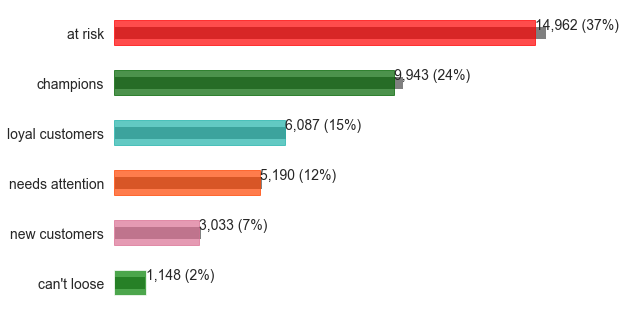

```python
fig = plt.figure()
fig.set_figwidth(9)
fig.set_figheight(6)

y=range(len(segments_counts))
ax = fig.add_axes([0,0,0.7,0.7])
bars0 = ax.barh(y, segments_counts, color = 'gray', height = 0.25, alpha=1, align='center')
bars = ax.barh(y, segments_counts_z, color = 'g', height = 0.5, linewidth=1, alpha=0.7)
ax.set_frame_on(False)
ax.tick_params(left=False,
               bottom=False,
               labelbottom=False)
ax.set_yticks(range(len(segments_counts_z)))
ax.set_yticklabels(segments_counts_z.index)
ax.yaxis.set_tick_params(rotation=0, labelsize=14)

for i, bar in enumerate(bars):
        value = bar.get_width()
        if segments_counts_z.index[i] in ['champions']:
            bar.set_color('#006400')
        if segments_counts_z.index[i] in ['loyal customers']:
            bar.set_color('#20B2AA')
        if segments_counts_z.index[i] in ['at risk']:
            bar.set_color('red')
        if segments_counts_z.index[i] in ['needs attention']:
            bar.set_color('#FF4500')
        if segments_counts_z.index[i] in ['new customers']:
            bar.set_color('#DB7093')
        ax.text(value,
                bar.get_y() + bar.get_height()/2,
                '{:,} ({:}%)'.format(int(value),
                                   int(value*100/segments_counts_z.sum())),
                va='bottom',
                ha='left',
                fontsize=14)
plt.show()
```

Выводы

**Группа "at_risk" осталась самой существенной. Не поменялась раскладка. С выбросами надо работать индивидуально, изменять исключения**

```python
t=rfm.merge(rfm_z[['RFM Score_z', 'Segment_z']], on='customer_id', how='left')
```

```python
t.head()
```

| customer_id | Recency | Frequency | Monetary | R | F | M | RFM Score | Segment | RFM Score_z | Segment_z |
| --- | --- | --- | --- | --- | --- | --- | --- | --- | --- | --- |
| c14618 | 31 | 24 | 31944 | 5 | 5 | 5 | 555 | champions | 555 | champions |
| c347 | 6 | 22 | 27993 | 5 | 5 | 5 | 555 | champions | 555 | champions |
| c6977 | 19 | 22 | 23005 | 5 | 5 | 5 | 555 | champions | 555 | champions |
| c41082 | 23 | 21 | 28923 | 5 | 5 | 5 | 555 | champions | 555 | champions |
| c15613 | 140 | 21 | 22829 | 3 | 5 | 5 | 355 | loyal customers | 355 | loyal customers |

# Вариант 3. ML. K-Means

```python
X = rfm[['Recency', 'Frequency', 'Monetary']].copy(deep=True)
```

```python
scaler = StandardScaler()
```

```python
# Остановились на методе трасформации данных
scaled_X = scaler.fit_transform(X)
```

```python
model = KMeans(n_clusters=6)
```

```python
cluster_labels = model.fit_predict(scaled_X)
```

```python
X['Cluster'] = cluster_labels
```

```python
X.head()
```

| customer_id | Recency | Frequency | Monetary | Cluster |
| --- | --- | --- | --- | --- |
| c14618 | 31 | 24 | 31944 | 3 |
| c347 | 6 | 22 | 27993 | 3 |
| c6977 | 19 | 22 | 23005 | 3 |
| c41082 | 23 | 21 | 28923 | 3 |
| c15613 | 140 | 21 | 22829 | 3 |

# Визуализируем зависимости между кластерами

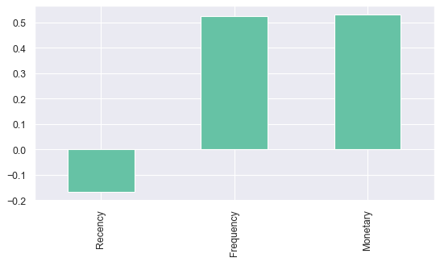

```python
plt.figure(figsize=(8,4),dpi=80)
X.corr()['Cluster'].iloc[:-1].sort_values().plot(kind='bar')
```

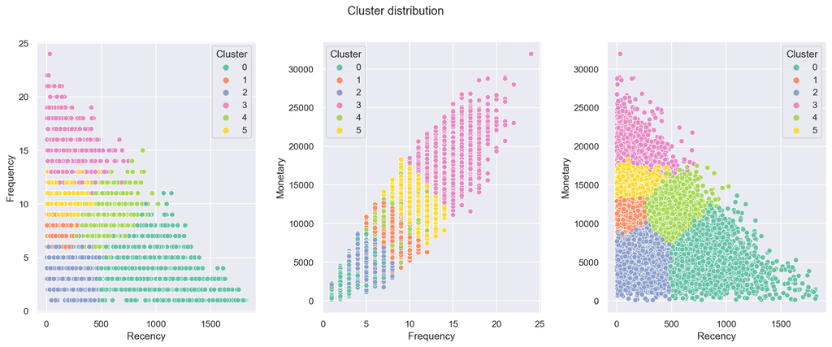

```python
plt.figure(figsize=(12, 6), dpi=150)
plt.subplots_adjust(wspace=0.3, hspace=1, left=0, right=1.1)
plt.suptitle('Cluster distribution', fontsize=14)
plt.subplot(131)
sns.scatterplot(x= X['Recency'], y= X['Frequency'], hue = X['Cluster'], palette = 'Set2')
plt.subplot(132)
sns.scatterplot(x= X['Frequency'], y= X['Monetary'], hue = X['Cluster'], palette = 'Set2')
plt.subplot(133)
sns.scatterplot(x= X['Recency'], y= X['Monetary'], hue = X['Cluster'], palette = 'Set2')
plt.show()
```

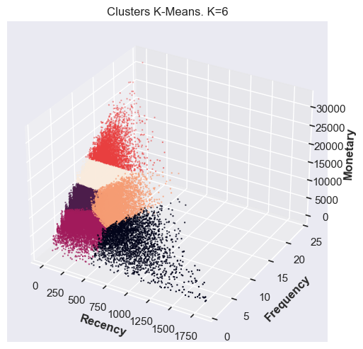

```python
fig = plt.figure(figsize=(6,6),dpi=100)
plt.get_cmap('Set2')
ax = fig.add_subplot(projection='3d')
xs = X['Recency']
ys = X['Frequency']
zs = X['Monetary']
d = ax.scatter(xs, ys, zs, c=X['Cluster'], s=0.5)

plt.title("Clusters K-Means. K=6")
ax.set_xlabel('Recency', fontweight ='bold')
ax.set_ylabel('Frequency', fontweight ='bold')
ax.set_zlabel('Monetary', fontweight ='bold')
# fig.colorbar(d, ax = ax, shrink = 0.2, aspect = 2)
plt.show()
```

**Машинное обучение разбило на установленные 6 групп нашу выборку:**

```python
rfm_total=t.merge(X['Cluster'], on='customer_id', how='left')
```

```python
rfm_total.drop(columns=['R','F','M'], inplace=True)
```

```python
segments_counts_Cluster = rfm_total.Cluster.value_counts().sort_values(ascending=True)
segments_counts_Cluster
```

```
0     2676
3     3998
4     5855
2     7473
5     9931
1    11249
Name: Cluster, dtype: int64
```

## Разбили на 6 групп клиентов. Интерпретируем. Не очень удобно размечать сегменты по имеющимся категориям (для сравнения). Ввиду участия в кластаризации Monetary. Изменяется нумерация при повторном запуске кода.

```python
cluster_name = {
    2: 'new customers',
    0: 'at risk',
    5: 'can\'t loose',
    4: 'needs attention',
    3: 'champions',
    1: 'loyal customers'
}

rfm_total['Segment_cluster'] = rfm_total['Cluster'].replace(to_replace=cluster_name)
rfm_total.head()
```

| customer_id | Recency | Frequency | Monetary | RFM Score | Segment | RFM Score_z | Segment_z | Cluster | Segment_cluster |
| --- | --- | --- | --- | --- | --- | --- | --- | --- | --- |
| c14618 | 31 | 24 | 31944 | 555 | champions | 555 | champions | 3 | champions |
| c347 | 6 | 22 | 27993 | 555 | champions | 555 | champions | 3 | champions |
| c6977 | 19 | 22 | 23005 | 555 | champions | 555 | champions | 3 | champions |
| c41082 | 23 | 21 | 28923 | 555 | champions | 555 | champions | 3 | champions |
| c15613 | 140 | 21 | 22829 | 355 | loyal customers | 355 | loyal customers | 3 | champions |

```python
segments_counts_Cluster = rfm_total.Segment_cluster.value_counts().sort_values(ascending=True)
segments_counts_Cluster
```

```
at risk             2676
champions           3998
needs attention     5855
new customers       7473
can't loose         9931
loyal customers    11249
Name: Segment_cluster, dtype: int64
```

# Группы новые клиенты (new customers) и "нельзя потерять" (can't loose) обширны. Возможно их следует расценивать по иному.

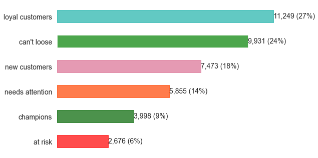

```python
fig = plt.figure()
fig.set_figwidth(9)
fig.set_figheight(6)

y=range(len(segments_counts_Cluster))
ax = fig.add_axes([0,0,0.7,0.7])
# bars0 = ax.barh(y, segments_counts, color = 'gray', height = 0.25, alpha=1, align='center')
bars = ax.barh(y, segments_counts_Cluster, color = 'g', height = 0.5, linewidth=1, alpha=0.7)
ax.set_frame_on(False)
ax.tick_params(left=False,
               bottom=False,
               labelbottom=False)
ax.set_yticks(range(len(segments_counts_Cluster)))
ax.set_yticklabels(segments_counts_Cluster.index)
ax.yaxis.set_tick_params(rotation=0, labelsize=14)

for i, bar in enumerate(bars):
        value = bar.get_width()
        if segments_counts_Cluster.index[i] in ['champions']:
            bar.set_color('#006400')
        if segments_counts_Cluster.index[i] in ['loyal customers']:
            bar.set_color('#20B2AA')
        if segments_counts_Cluster.index[i] in ['at risk']:
            bar.set_color('red')
        if segments_counts_Cluster.index[i] in ['needs attention']:
            bar.set_color('#FF4500')
        if segments_counts_Cluster.index[i] in ['new customers']:
            bar.set_color('#DB7093')
        ax.text(value,
                bar.get_y() + bar.get_height()/2,
                '{:,} ({:}%)'.format(int(value),
                                   int(value*100/segments_counts_Cluster.sum())),
                va='center',
                ha='left',
                fontsize=14)
plt.show()
```

Выводы

**Машинное обучение разбило на установленные 6 групп нашу выборку: Всё очень изменилось. Основная группа обозначена как "loyal customers". Хотя стоит изменить название кластеров на что-то вроде "большая сумма/давно покупали/редко". Но делать этого не будем в связи с сопоставлением разных подходов**

# Сравним "человеческий" и "машинный" способы сегментации

```python
rfm_total.sample(frac=1).head(50)
```

| customer_id | Recency | Frequency | Monetary | RFM Score | Segment | RFM Score_z | Segment_z | Cluster | Segment_cluster |
| --- | --- | --- | --- | --- | --- | --- | --- | --- | --- |
| c2718 | 1284 | 2 | 1337 | 111 | at risk | NaN | NaN | 0 | at risk |
| c14157 | 836 | 5 | 4976 | 111 | at risk | 111 | at risk | 0 | at risk |
| c30722 | 171 | 9 | 10234 | 333 | needs attention | 333 | needs attention | 1 | loyal customers |
| c17043 | 159 | 10 | 10726 | 344 | loyal customers | 343 | loyal customers | 5 | can't loose |
| c2717 | 49 | 4 | 4297 | 511 | new customers | 511 | new customers | 2 | new customers |
| c25409 | 20 | 6 | 6317 | 511 | new customers | 511 | new customers | 2 | new customers |
| c33978 | 264 | 14 | 11143 | 254 | can't loose | 254 | can't loose | 5 | can't loose |
| c16639 | 318 | 4 | 6431 | 211 | at risk | 211 | at risk | 2 | new customers |
| c20047 | 255 | 9 | 11398 | 234 | at risk | 234 | at risk | 5 | can't loose |
| c36477 | 576 | 2 | 2288 | 111 | at risk | 111 | at risk | 0 | at risk |
| c34105 | 27 | 9 | 10581 | 533 | champions | 533 | champions | 1 | loyal customers |
| c16376 | 10 | 7 | 9440 | 523 | champions | 523 | champions | 1 | loyal customers |
| c3741 | 215 | 9 | 13830 | 235 | at risk | 235 | at risk | 5 | can't loose |
| c24159 | 39 | 5 | 8485 | 512 | new customers | 512 | new customers | 1 | loyal customers |
| c8286 | 60 | 11 | 9109 | 443 | loyal customers | 443 | loyal customers | 5 | can't loose |
| c8272 | 77 | 5 | 5154 | 411 | new customers | 411 | new customers | 2 | new customers |
| c12108 | 100 | 9 | 10927 | 434 | champions | 434 | champions | 1 | loyal customers |
| c9240 | 101 | 5 | 6333 | 411 | new customers | 411 | new customers | 2 | new customers |
| c34898 | 298 | 6 | 7457 | 212 | at risk | 212 | at risk | 2 | new customers |
| c26549 | 137 | 7 | 9623 | 323 | needs attention | 323 | needs attention | 1 | loyal customers |
| c12929 | 18 | 7 | 7530 | 522 | champions | 522 | champions | 1 | loyal customers |
| c33549 | 224 | 8 | 12470 | 234 | at risk | 234 | at risk | 5 | can't loose |
| c21712 | 78 | 15 | 17078 | 455 | loyal customers | 455 | loyal customers | 3 | champions |
| c7930 | 85 | 14 | 10638 | 453 | loyal customers | 453 | loyal customers | 5 | can't loose |
| c4297 | 327 | 9 | 9393 | 233 | at risk | 233 | at risk | 4 | needs attention |
| c23556 | 398 | 6 | 3828 | 111 | at risk | 111 | at risk | 2 | new customers |
| c15633 | 85 | 8 | 10755 | 434 | champions | 434 | champions | 1 | loyal customers |
| c33973 | 612 | 3 | 3660 | 111 | at risk | 111 | at risk | 0 | at risk |
| c16467 | 424 | 2 | 2454 | 111 | at risk | 111 | at risk | 2 | new customers |
| c917 | 255 | 6 | 6294 | 211 | at risk | 211 | at risk | 2 | new customers |
| c23601 | 61 | 5 | 5453 | 411 | new customers | 411 | new customers | 2 | new customers |
| c32338 | 32 | 16 | 19707 | 555 | champions | 555 | champions | 3 | champions |
| c35450 | 39 | 6 | 5814 | 511 | new customers | 511 | new customers | 2 | new customers |
| c28852 | 8 | 13 | 17040 | 555 | champions | 555 | champions | 3 | champions |
| c35056 | 253 | 7 | 9940 | 223 | at risk | NaN | NaN | 1 | loyal customers |
| c39100 | 272 | 7 | 8616 | 222 | at risk | 222 | at risk | 1 | loyal customers |
| c22697 | 334 | 6 | 5430 | 211 | at risk | 211 | at risk | 2 | new customers |
| c6084 | 60 | 5 | 6285 | 411 | new customers | 411 | new customers | 2 | new customers |
| c26923 | 767 | 4 | 4417 | 111 | at risk | 111 | at risk | 0 | at risk |
| c25398 | 326 | 8 | 11112 | 234 | at risk | 234 | at risk | 4 | needs attention |
| c31028 | 266 | 7 | 10240 | 223 | at risk | 223 | at risk | 1 | loyal customers |
| c26354 | 11 | 11 | 14801 | 545 | champions | 545 | champions | 5 | can't loose |
| c23119 | 932 | 6 | 7356 | 112 | at risk | 112 | at risk | 0 | at risk |
| c41079 | 98 | 14 | 16300 | 455 | loyal customers | 455 | loyal customers | 3 | champions |
| c9209 | 71 | 10 | 11545 | 444 | loyal customers | 444 | loyal customers | 5 | can't loose |
| c35876 | 21 | 7 | 7625 | 522 | champions | 522 | champions | 1 | loyal customers |
| c302 | 60 | 4 | 6351 | 411 | new customers | 411 | new customers | 2 | new customers |
| c37915 | 60 | 8 | 8725 | 433 | champions | 433 | champions | 1 | loyal customers |
| c31533 | 670 | 10 | 7926 | 142 | at risk | 142 | at risk | 4 | needs attention |
| c5397 | 441 | 5 | 4552 | 111 | at risk | 111 | at risk | 2 | new customers |

**Выводы:**

1. За основу желательно брать классификацию "ручным способом". Так можно оттолкнуться и понять к какому сегменту визуально явно можно отнести клиента;

2. Применяя статистику, в частности Z-нормализации можно обосновать выбросы или аномалии. В последствии, их можно исключить из выборки. Делать это надо разбираясь в сфере. В нашем анализе даже отсечение 1% приводит к негативному пропуску волонтильных клиентов;

3. Хорошо подходит метод машинного обучения без супервайзера K-means для кластеризации. Видоизменяет сегментацию относительно способа деления на равные части. Однако при повторном запуске кода сбивается нумерация секторов, что приводит к необходимости повторной интерпретации. Отлично подходит, если мы не знаем на сколько групп разбивать выборку. Т.к. для этого существует несколько принципиальных подходов ("колена", ssd), а также моделей обучения, позволяющим предположить оптимальное количество кластеров